# Problématique de notre sujet

Mathis Boutin - Romain Jegoux - Mattéo Rouanne - Maxime Tougard

24/10/2023

# 1. Import des données

```r
traffic <- read.csv("traffic_adp.csv", sep=";")
```

## 1.1 Création de la série temporelle

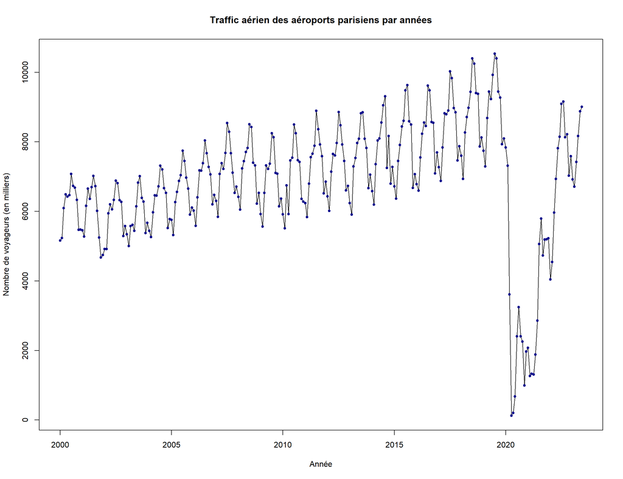

```r
traffic$totpass = (traffic$passenger_CdG + traffic$passenger_orly)/1000
ts_traffic = ts(traffic$totpass, start = c(2000, 1),frequency = 12)

plot(ts_traffic, xlab = "Année", ylab = "Nombre de voyageurs (en milliers)", main = "Traffic aérien des aéroports parisiens par années")
points(ts_traffic, col= "darkblue", pch = 20)
```

# 2. Prédiction du nombre de voyageur sans la pandemie de Covid-19

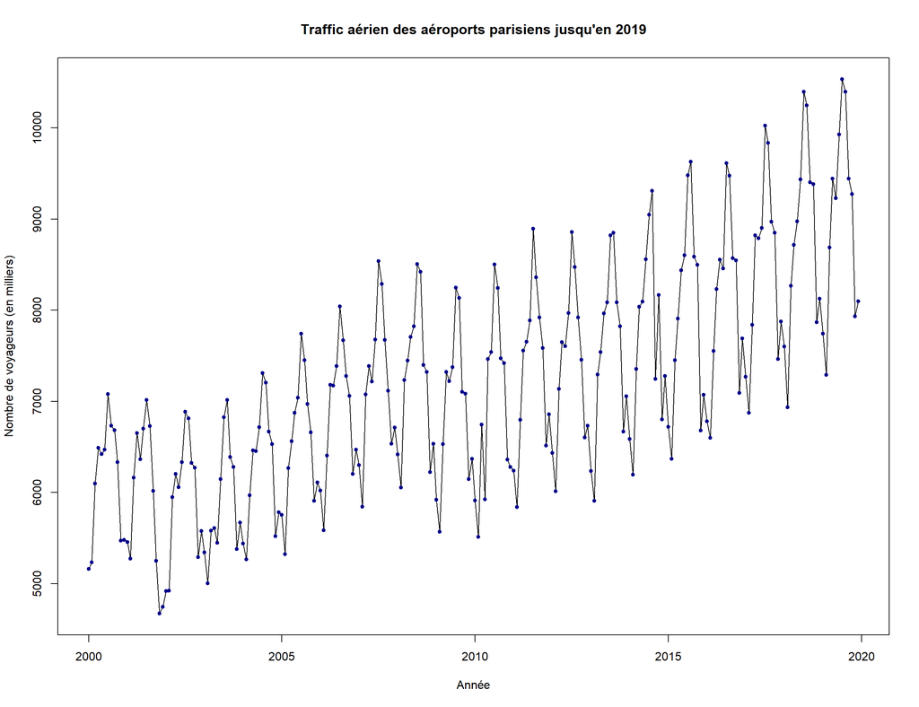

```r
#On enlève les années après 2019
traffic_2000_2019 = window(ts_traffic,end= c(2019,12))
plot(traffic_2000_2019 ,xlab="Année", ylab= "Nombre de voyageurs (en milliers)", main = "Traffic aérien des aéroports parisiens jusqu'en 2019")
points(traffic_2000_2019, col= "darkblue", pch = 20)
```

On retire les années après 2019 car la crise du covid-19 a fortement impactée le traffic aérien de cette période. On va donc estimer les voyageurs de cette période a l’aide des années précedentes afin de voir l’impact réel de cette crise

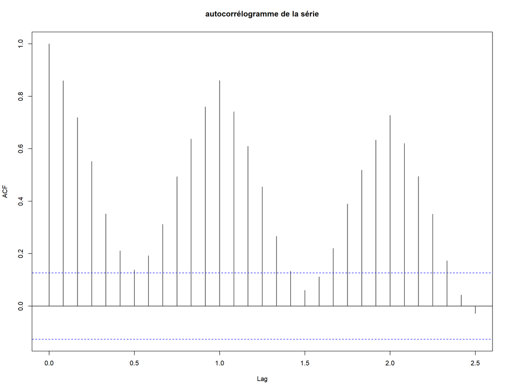

```r
acf(traffic_2000_2019,lag.max = 30, main= "autocorrélogramme de la série" )
```

Sur cet autocorrelogramme on detecte une forte corrélation tous les 1 de lag soit toutes les années il y a donc une saisonnalité de période 12

## 2.1 Calcul de la tendance

### 2.1.1 Determination du modèle de la tendance

```r
p = 1:length(traffic_2000_2019)  #longueur de la série
tend_traffic = lm(traffic_2000_2019~p) #modèle linéaire
tend_traffic2 = lm(traffic_2000_2019~p + I(p^2)) #modèle polynomial de degré 2
tend_traffic3 = lm(traffic_2000_2019~p + I(p^2) + I(p^3)) #modèle polynomial de degré 3

cat ("le R2 du modèle linéaire vaut",cor(traffic_2000_2019, p)^2, "\n") # R2 du modèle linéaire
```

```
## le R2 du modèle linéaire vaut 0.5246034
```

```r
cat ("le R2 du modèle polynomial de degré 2 vaut",cor(traffic_2000_2019, p + I(p^2))^2 , "\n")# R2 du modèle polynomial de degré 2
```

```
## le R2 du modèle polynomial de degré 2 vaut 0.5223659
```

```r
cat ("le R2 du modèle polynomial de degré 3 vaut",cor(traffic_2000_2019, p + I(p^2)  + I(p^3))^2, "\n" ) # R2 du modèle polynomial de degré 3
```

```
## le R2 du modèle polynomial de degré 3 vaut 0.4923603
```

On choisi donc le modèle linéaire car il a le $R^2$ le plus grand

### 2.1.2 Création de la série temporelle de la tendance

```r
fittedval = ts(data = tend_traffic$fitted.values, start = c(2000, 1), frequency = 12)
tend_traffic$coefficients
```

```
## (Intercept)           p
##  5655.79928    12.90419
```

On a choisi un modèle linéaire pour estimer la tendance et on récupere donc ses coefficients $\hat \beta_0$ et $\hat \beta_1$

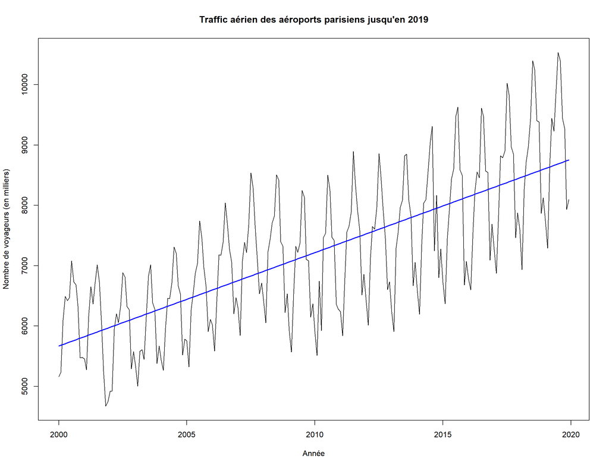

```r
plot(traffic_2000_2019, main = "Traffic aérien des aéroports parisiens jusqu'en 2019" , xlab= "Année", ylab ="Nombre de voyageurs (en milliers)" )
lines(fittedval , col="blue", lwd = 2)
```

On voit ici la tendance linéaire que l’on a calculé, affichée sur la serie réelle

## 2.2 Estimation de la saisonnalité

### 2.2.1 Élimination de la tendance

On élimine la tendance par différenciation

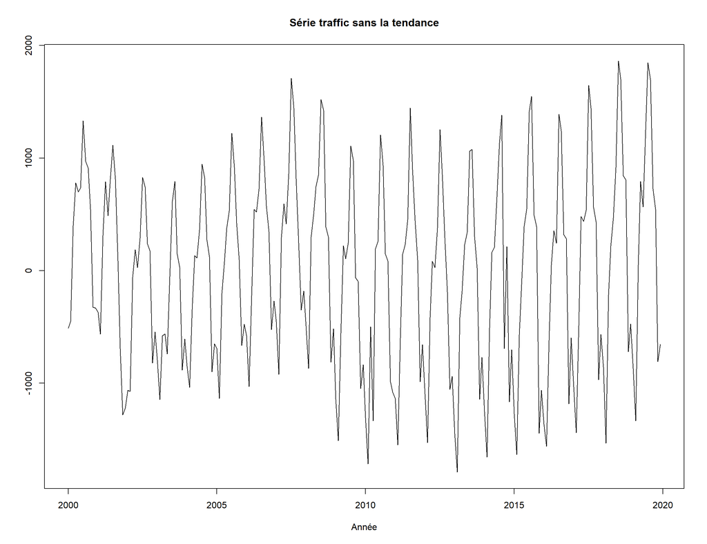

```r
notend = traffic_2000_2019 - fittedval
plot(notend , main= "Série traffic sans la tendance", xlab="Année",ylab ="")
```

### 2.2.2 Calcul de la saisonalité

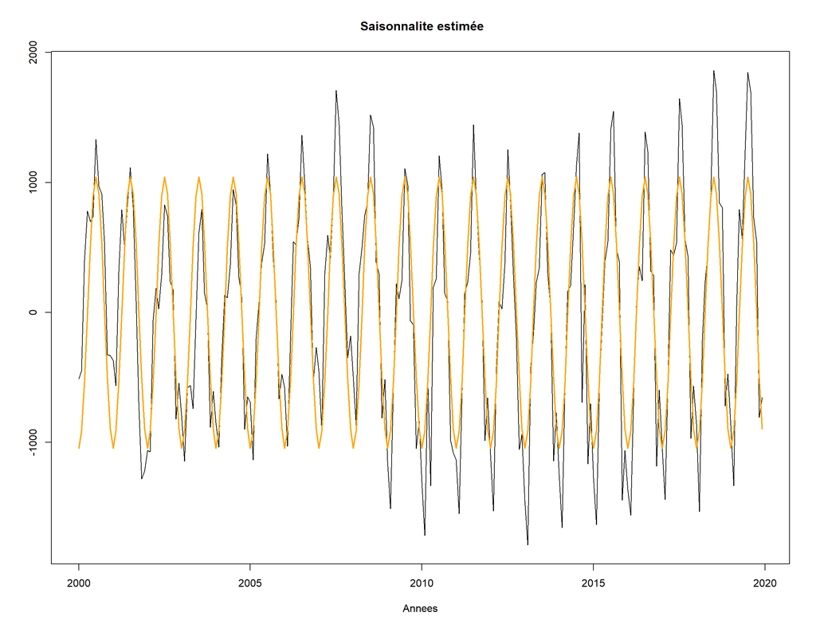

```r
T = 12
nb_NA = sum(is.na(tend_traffic))/2
t = (nb_NA + 1):(length(notend) - nb_NA)

sint <-sin((2*pi*t)/T)
cost <-cos((2*pi*t)/T)

plot (notend, xlab ="Annees", ylab =" ", main =" Saisonnalite estimée")
sais_1 = lm(notend[t]~sint + cost )
sais_2 <- ts(sais_1$fit, start = 2000 , freq = 12)
lines(sais_2, col="orange", lwd= 2)
```

```r
N = 120
n = (length(traffic_2000_2019) + 1):(length(traffic_2000_2019) + N)
df_sais = data.frame(matrix(c(sin(2*pi*n/T), cos(2*pi*n/T)), ncol = 2))
colnames(df_sais) = c("sint", "cost")
pred_tend = predict(sais_1, newdata = df_sais)
```

```r
i = (length(traffic_2000_2019) + 1):(length(traffic_2000_2019) + N)
df_tend = data.frame(i)
colnames(df_tend) = c("p")
pred_sais = predict(tend_traffic, newdata = df_tend)

pred_tend_sais = ts(data = pred_tend+pred_sais, start = c(2020,1), frequency = 12)
ajust= ts(data =tend_traffic$fitted.values+sais_1$fitted.values, start = c(2000,1), frequency = 12)
```

## 2.3 Prédiction à l’aide du modèle

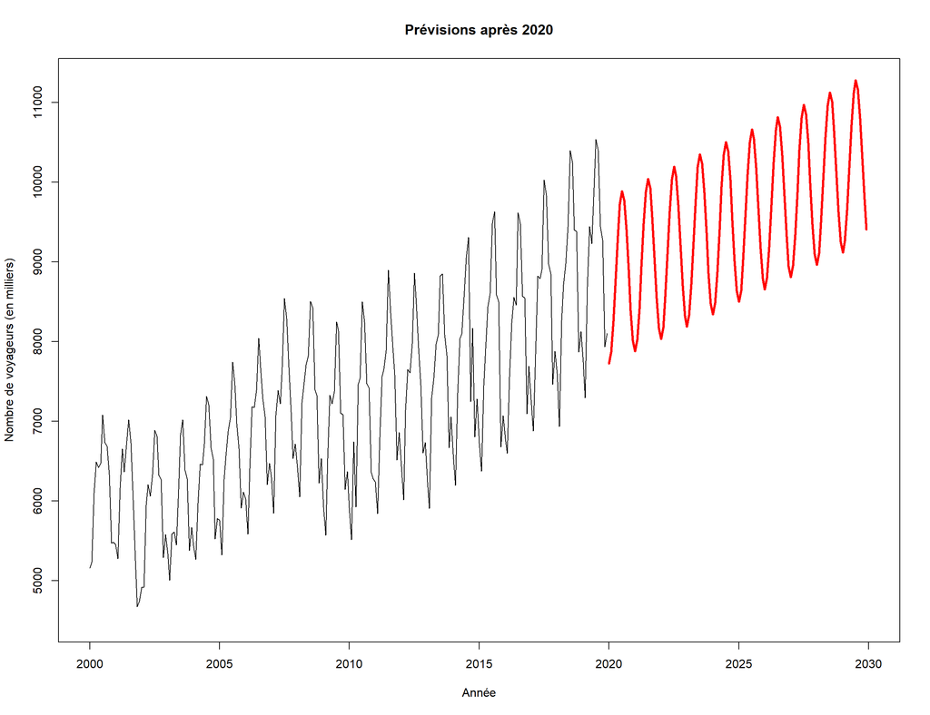

```r
plot(traffic_2000_2019, xlim = c(2000,2020 + N/12),ylim=c(4500,max(pred_tend_sais)),main = "Prévisions après 2020",xlab="Année" ,ylab = "Nombre de voyageurs (en milliers)")
lines(pred_tend_sais, lwd = 3,col = "red")
```

# 3. Prédiction du nombre de voyageur à l’aide des données post-covid

On choisi de faire cette étude sur les données post covid. On crée donc un série temporelle sur les données a partir d’avril 2022 soit 2 ans après le confinement. On a pu remarquer sur les graphiques précédents qu’il semblait y avoir une reprise a la normale du traffic aérien a cette période. Il faut toutefois relativiser puisque les prédictions se basent sur les données entre avril 2022 à juin 2023 il y a donc peu d’observations.

## 3.1 Création de la série post covid

```r
traffic_post_cov = window(ts_traffic,start= c(2022,4))
```

## 3.2 Calcul de la tendance

### 3.2.1 Choix du modèle pour représenter la tendance

```r
p = 1:length(traffic_post_cov)  #longueur de la série
tend_traffic_c = lm(traffic_post_cov~p) #modèle linéaire
tend_traffic2_c = lm(traffic_post_cov~p + I(p^2)) #modèle polynomial de degré 2

cat ("le R2 du modèle linéaire vaut",cor(traffic_post_cov, p)^2, "\n") # R2 du modèle linéaire
```

```
## le R2 du modèle linéaire vaut 0.005476107
```

```r
cat ("le R2 du modèle polynomial de degré 2 vaut",cor(traffic_post_cov, p + I(p^2))^2 , "\n")# R2 du modèle polynomial de degré 2
```

```
## le R2 du modèle polynomial de degré 2 vaut 0.01544017
```

### 3.2.2 Création série temporelle de la tendance

```r
fittedval_c = ts(data = tend_traffic_c$fitted.values, start = c(2022, 4), frequency = 12)
tend_traffic_c$coefficients
```

```
## (Intercept)           p
##  7835.89736    13.87357
```

On a choisi un modèle linéaire pour estimer la tendance et on récupere donc ses coefficients $\hat \beta_0$ et $\hat \beta_1$

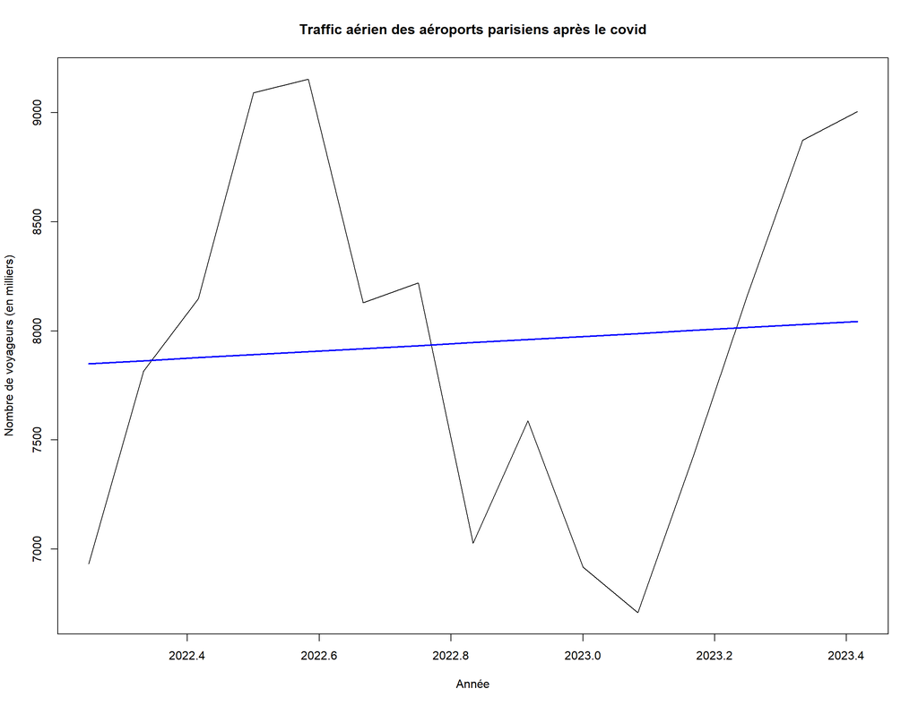

```r
plot(traffic_post_cov, main = "Traffic aérien des aéroports parisiens après le covid" , xlab= "Année", ylab ="Nombre de voyageurs (en milliers)" )
lines(fittedval_c , col="blue", lwd = 2)
```

## 3.3 Estimation de la saisonnalité

### 3.3.1 Élimination de la tendance

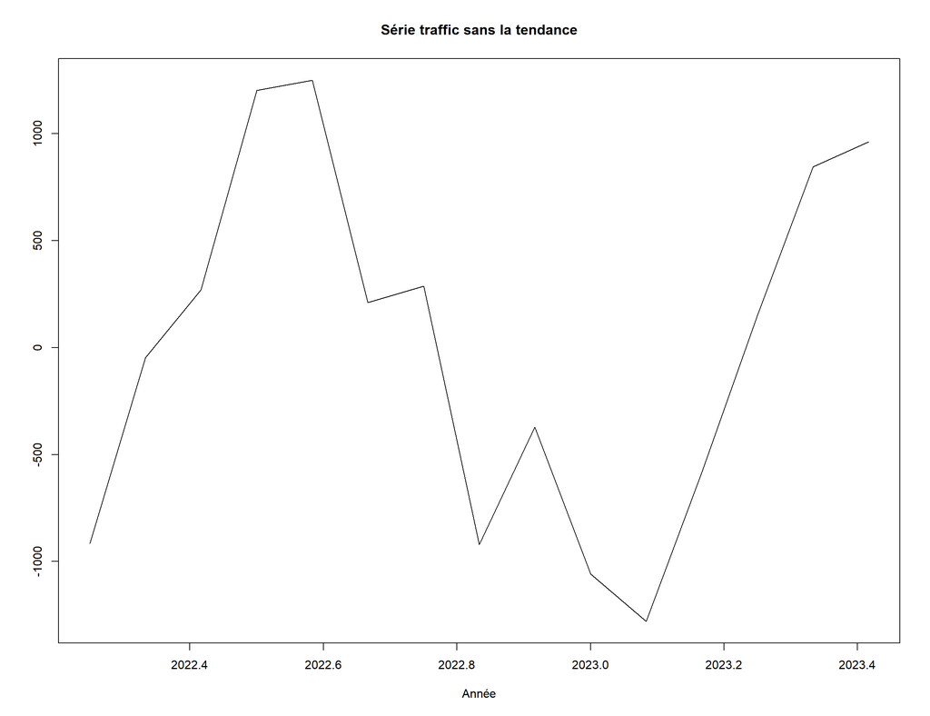

```r
notend_c = traffic_post_cov - fittedval_c
plot(notend_c , main= "Série traffic sans la tendance", xlab="Année",ylab ="")
```

On élimine la tendance par différenciation

### 3.3.2 Éstimation de la saisonnalité

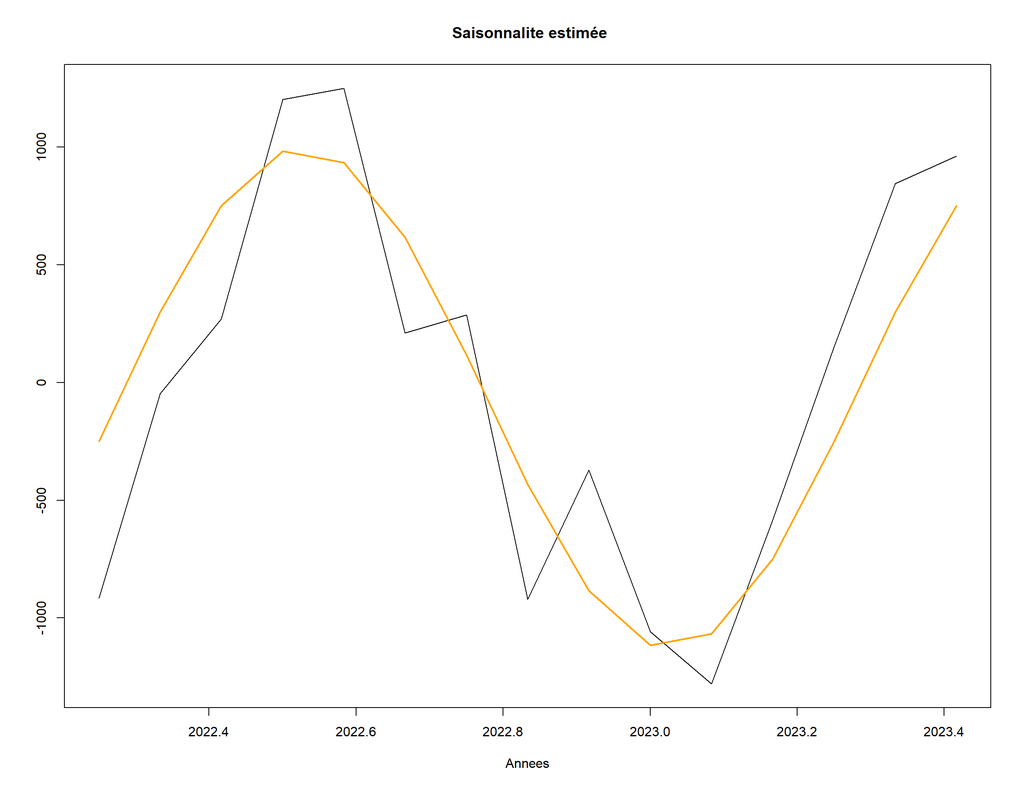

```r
T = 12
nb_NA = sum(is.na(tend_traffic_c))/2
t = (nb_NA + 1):(length(notend_c) - nb_NA)

sint <-sin((2*pi*t)/T)
cost <-cos((2*pi*t)/T)

plot (notend_c, xlab ="Annees", ylab =" ", main =" Saisonnalite estimée")
sais_1 = lm(notend_c[t]~sint + cost )
sais_2 <- ts(sais_1$fit, start = c(2022,4) , freq = 12)
lines(sais_2, col="orange", lwd= 2)
```

## 3.4 Prédiction a l’aide du modèle

```r
C19 = 76
n = (length(traffic_post_cov) + 1):(length(traffic_post_cov) + C19)
df_sais = data.frame(matrix(c(sin(2*pi*n/T), cos(2*pi*n/T)), ncol = 2))
colnames(df_sais) = c("sint", "cost")
pred_tend = predict(sais_1, newdata = df_sais)
```

```r
i = (length(traffic_post_cov) + 1):(length(traffic_post_cov) + C19)
df_tend = data.frame(i)
colnames(df_tend) = c("p")
pred_sais = predict(tend_traffic_c, newdata = df_tend)
```

### 3.4.3 Prédiction selon le modèle

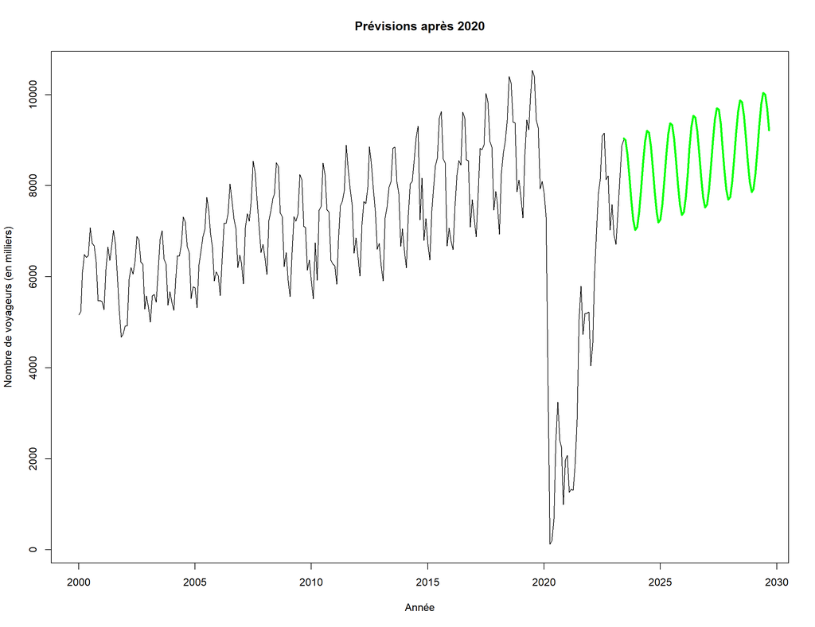

```r
pred_tend_sais_c = ts(data = pred_tend+pred_sais, start = c(2023,6), frequency = 12)
ajust= ts(data =tend_traffic$fitted.values+sais_1$fitted.values, start = c(2000,1), frequency = 12)

plot(ts_traffic, xlim = c(2000,2023 + C19/12),main = "Prévisions après 2020",xlab="Année" ,ylab = "Nombre de voyageurs (en milliers)")
lines(pred_tend_sais_c, lwd = 3,col = "green")
```

# 4. Comparaison des deux Prévisions

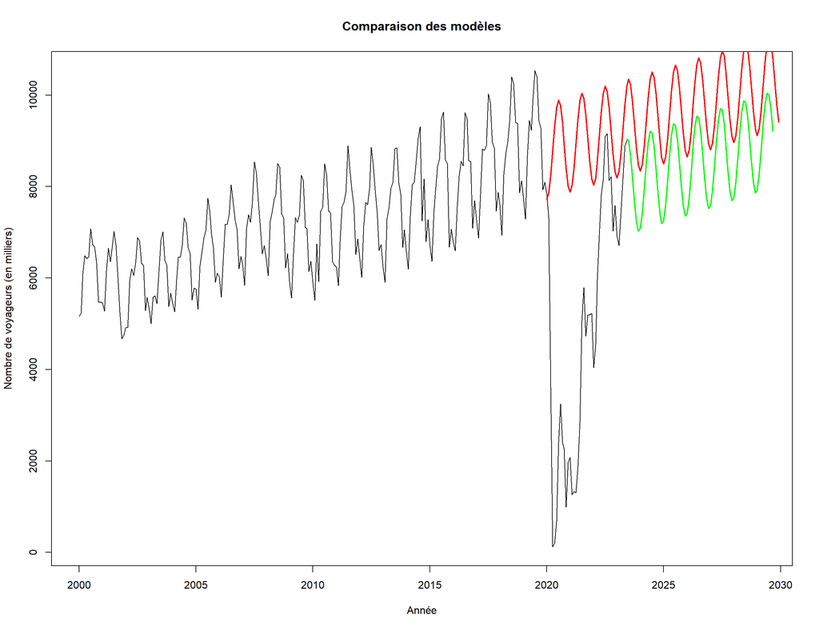

```r
plot(ts_traffic, xlim = c(2000,2023 + C19/12),main = "Comparaison des modèles",xlab="Année" ,ylab = "Nombre de voyageurs (en milliers)")
lines(pred_tend_sais_c, lwd = 2,col = "green")
lines(pred_tend_sais, lwd = 2,col = "red")
```